# P01 金融数据分析报告

本报告基于 `01_download.ipynb` 和 `02_clean.ipynb` 生成的数据，完成数据说明、清洗说明、描述统计、图表分析、CAPM 回归和宏观变量回归。报告可独立阅读；即使不打开 Notebook，也能理解数据来源、处理方法和主要发现。

## 1. 数据说明

本报告使用 10 只 A 股股票的后复权日度行情，样本区间为 2020-01-02 至 2026-05-15，覆盖行业包括 房地产、汽车、物流、白酒、能源、通讯、银行。市场基准使用沪深 300，辅助市场指数使用上证综指；宏观指标包括 CPI 同比、人民币/美元汇率、M2 同比、1 年期 LPR 和工业增加值增速，财务指标包括 ROE、净利润率、资产负债率和营业收入增速。

股票行情、指数数据、宏观指标和财务指标均保存为 CSV，清洗后的核心分析表为 `data/combined/combined_data.csv`。股票日收益率和 CAPM 均使用日对数收益率，市场基准为沪深 300；宏观分析使用月度数据以匹配宏观指标频率。

## 2. 清洗说明

清洗步骤在 `02_clean.ipynb` 中完成。每只股票的原始表先检测缺失值和重复值，再统一日期格式为 `datetime64[ns]`，并将价格、成交量和成交额字段转换为数值型。缺失的数值型字段采用向前填充，仍无法补齐的关键记录删除；重复记录按 `date + code` 删除；单日涨跌幅超过 +/-20% 的记录标注为 `is_extreme=True`，但不删除。

随后将 10 只股票的收盘价转换为宽表和长表，并将个股日度数据与沪深 300、上证综指按日期左连接。月度宏观指标通过 `YYYY-MM` 月份键映射到对应月份的每日交易数据，保证日度股票样本行数不因合并宏观数据而改变。

## 3. 分析环境和股票列表

下面代码读取清洗后的综合数据，统一股票代码格式，计算日对数收益率，并展示本报告使用的股票列表。所有图形输出到 `output/` 文件夹，PNG 分辨率不低于 150 dpi。

|  | code | name | industry |
| --- | --- | --- | --- |
| 0 | 000002 | 万科A | 房地产 |
| 5 | 002594 | 比亚迪 | 汽车 |
| 3 | 601127 | 赛力斯 | 汽车 |
| 7 | 002352 | 顺丰控股 | 物流 |
| 8 | 000858 | 五粮液 | 白酒 |
| 1 | 600519 | 贵州茅台 | 白酒 |
| 9 | 601088 | 中国神华 | 能源 |
| 4 | 300308 | 中际旭创 | 通讯 |
| 2 | 600036 | 招商银行 | 银行 |
| 6 | 601398 | 工商银行 | 银行 |

## 4.1 基本统计量

日收益率使用公式 $r_t=\ln(P_t/P_{t-1})$ 计算。年化均值按日均收益率乘以 252，年化波动率按日收益率标准差乘以 $\sqrt{252}$，最大回撤基于收盘价相对历史高点的跌幅计算。

|  | 股票 | 行业 | 年化均值 | 年化波动率 | 偏度 | 峰度 | 最大回撤 |
| --- | --- | --- | --- | --- | --- | --- | --- |
| 0 | 000002 万科A | 房地产 | -31.94% | 36.26% | 0.65 | 3.26 | -86.85% |
| 3 | 002594 比亚迪 | 汽车 | 29.82% | 43.11% | 0.31 | 2.11 | -52.54% |
| 8 | 601127 赛力斯 | 汽车 | 32.71% | 61.69% | 0.36 | 0.86 | -71.71% |
| 2 | 002352 顺丰控股 | 物流 | 0.69% | 32.25% | 0.38 | 3.61 | -70.77% |
| 1 | 000858 五粮液 | 白酒 | -4.14% | 34.38% | 0.09 | 3.35 | -70.61% |
| 6 | 600519 贵州茅台 | 白酒 | 5.05% | 27.62% | 0.26 | 3.62 | -47.48% |
| 7 | 601088 中国神华 | 能源 | 22.58% | 29.95% | 0.31 | 3.24 | -21.45% |
| 4 | 300308 中际旭创 | 通讯 | 54.54% | 58.93% | 0.54 | 3.96 | -64.56% |
| 5 | 600036 招商银行 | 银行 | 4.03% | 27.56% | 0.27 | 3.21 | -50.94% |
| 9 | 601398 工商银行 | 银行 | 9.14% | 16.26% | 0.45 | 5.76 | -20.17% |

## 4.2 图 1：归一化收盘价走势图

将每只股票和沪深 300 的起点统一为 1，可以比较不同价格水平资产的累计表现。股票线条按行业着色，沪深 300 使用黑色虚线作为市场基准。

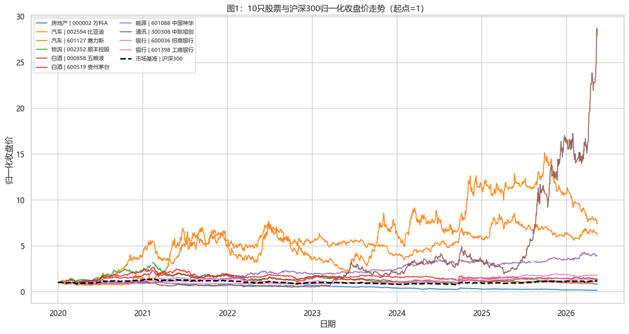

归一化走势显示，样本期内表现最好的是 中际旭创（300308，通讯），累计涨幅约为 2695.45%；表现最弱的是 万科A，累计变化约为 -85.78%。沪深 300 同期累计变化约为 17.04%，个股之间的分化明显大于市场基准，说明行业景气度和公司基本面对收益路径影响很大。

## 图 2：日收益率分布图

下图为 10 只股票日对数收益率的分面直方图，并叠加同均值、同标准差的正态分布曲线。每个子图标注该股票样本期内的日均收益率和日标准差。

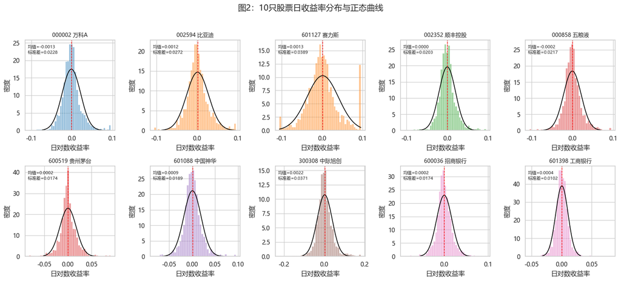

日收益率分布整体集中在 0 附近，但多个股票存在尖峰厚尾特征，说明极端涨跌的概率高于正态分布假设。其中 赛力斯 的日收益率标准差最高，万科A 的偏度绝对值较大，提示后续回归或风险分析不宜只依赖均值和方差。

## 图 3：收益率相关系数热力图

热力图使用 10 只股票的日对数收益率计算 Pearson 相关系数。股票按行业排序，便于观察同行业股票是否比跨行业股票更同步。

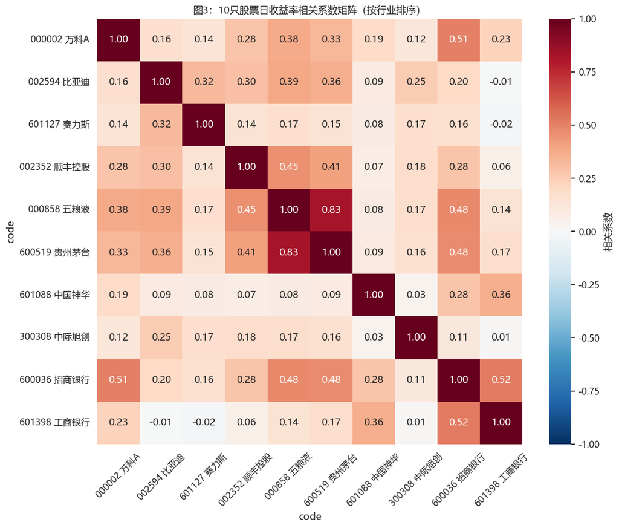

相关系数热力图按行业排序后，可以比较同行业与跨行业股票的联动程度。本样本中同行业股票平均相关系数约为 0.56，跨行业平均相关系数约为 0.21；如果同行业均值更高，通常反映共同基本面、政策和景气周期带来的同步波动。

## 图 4：宏观指标与股市关系

选择 M2 同比增速作为宏观指标。M2 代表广义货币供给，通常用于观察市场流动性环境；这里将其与沪深 300 月度对数收益率进行散点和线性拟合分析。

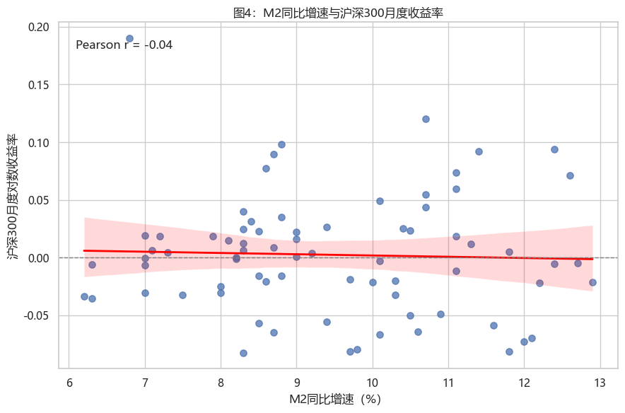

本图选择 M2 同比增速作为宏观指标，Pearson 相关系数约为 -0.04。若拟合线向上，表示流动性扩张通常与权益市场收益改善相关；若斜率较弱或相关性接近 0，则说明月度市场收益还受到盈利预期、风险偏好和外部冲击等因素共同影响。

## 图 5（选做）：财务指标跨公司对比

下图使用财务长表中的 ROE 指标，展示最近 5 年各公司的 ROE 变化，并按行业着色。ROE 是净资产收益率，能反映公司使用股东权益创造利润的能力。

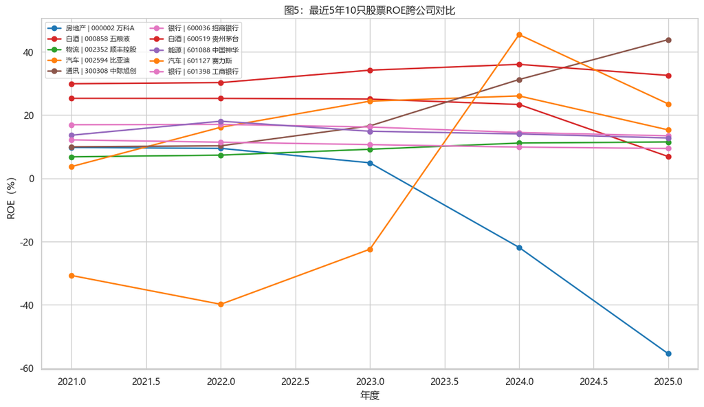

ROE 对比显示，最近 5 年不同公司的盈利能力差异明显，最新年度 ROE 最高的是 中际旭创（通讯），约为 43.84%。按行业均值看，白酒 行业 ROE 水平相对较高；ROE 趋势的持续上行通常意味着资本使用效率改善，而持续下行可能反映周期压力或盈利能力走弱。

# 第五部分：回归分析

本部分使用 `statsmodels.OLS` 完成 CAPM 模型估计，并使用月度数据分析宏观指标对个股收益率的影响。CAPM 的市场基准为沪深 300，年化无风险利率统一设为 2.0%，日频换算为 `0.02 / 252`。

## 5.1 CAPM 模型估计

对 10 只股票分别估计 CAPM 模型：

$$r_{i,t}-r_f=\alpha_i+\beta_i(r_{m,t}-r_f)+\epsilon_{i,t}$$

其中，$r_{i,t}$ 为个股日对数收益率，$r_{m,t}$ 为沪深 300 日对数收益率，$r_f$ 为日频无风险利率。

|  | 股票 | 行业 | alpha_hat | p值(alpha) | beta_hat | 95% CI | R² |
| --- | --- | --- | --- | --- | --- | --- | --- |
| 0 | 000002 万科A | 房地产 | -0.00137 | 0.006 | 1.00 | [0.92, 1.09] | 0.27 |
| 3 | 002594 比亚迪 | 汽车 | 0.00108 | 0.062 | 1.27 | [1.18, 1.37] | 0.31 |
| 8 | 601127 赛力斯 | 汽车 | 0.00118 | 0.205 | 1.13 | [0.98, 1.28] | 0.12 |
| 2 | 002352 顺丰控股 | 物流 | -0.00005 | 0.910 | 0.87 | [0.79, 0.94] | 0.26 |
| 1 | 000858 五粮液 | 白酒 | -0.00027 | 0.491 | 1.27 | [1.21, 1.34] | 0.49 |
| 6 | 600519 贵州茅台 | 白酒 | 0.00010 | 0.767 | 0.96 | [0.91, 1.02] | 0.43 |
| 7 | 601088 中国神华 | 能源 | 0.00082 | 0.081 | 0.40 | [0.32, 0.48] | 0.06 |
| 4 | 300308 中际旭创 | 通讯 | 0.00205 | 0.015 | 1.40 | [1.26, 1.54] | 0.20 |
| 5 | 600036 招商银行 | 银行 | 0.00006 | 0.863 | 0.89 | [0.84, 0.95] | 0.37 |
| 9 | 601398 工商银行 | 银行 | 0.00028 | 0.271 | 0.22 | [0.17, 0.26] | 0.06 |

### CAPM 表格说明

表中 `alpha_hat` 是控制市场超额收益后的平均异常收益，`beta_hat` 是个股相对沪深 300 的系统性风险暴露。`95% CI` 是 beta 的 95% 置信区间，若区间整体高于 1，说明该股票在样本期内显著高于市场弹性；若区间包含 1，则 beta 与市场弹性的差异未必稳健。

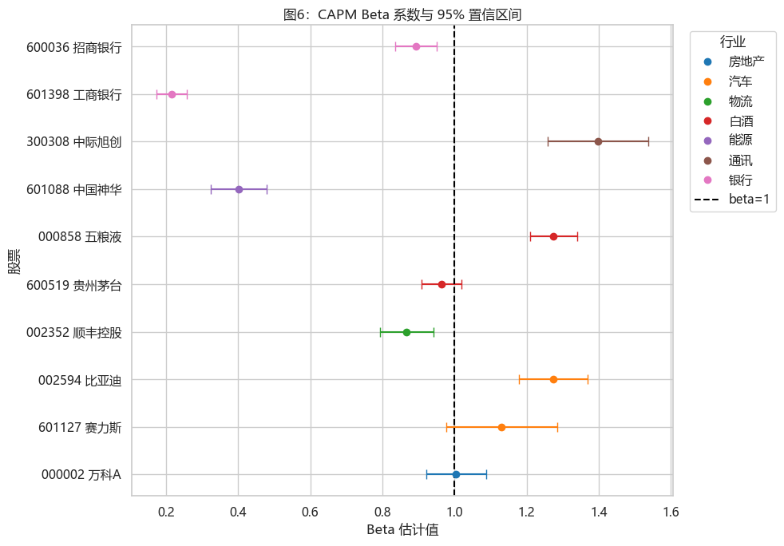

CAPM 结果中 beta 大于 1 的股票包括：中际旭创（通讯，β=1.40）、五粮液（白酒，β=1.27）、比亚迪（汽车，β=1.27）、赛力斯（汽车，β=1.13）、万科A（房地产，β=1.00）。这些股票对市场波动更敏感，更接近周期性或高弹性资产特征；beta 小于 1 的股票相对防御，但行业属性并不是唯一解释，公司自身经营周期和估值波动也会影响 beta。

Alpha 显著性检验结果显示，万科A（alpha=-0.00137, p=0.006）、中际旭创（alpha=0.00205, p=0.015）。显著 alpha 通常意味着样本期内该股票存在 CAPM 无法解释的超额收益或亏损，但也可能来自遗漏风险因子、行业冲击或样本期特殊事件。

R² 最高的是 五粮液（R²=0.49），最低的是 工商银行（R²=0.06）。R² 高说明该股票日收益中较大比例可由沪深 300 解释；R² 低则说明个股特质、行业事件或非市场因子占比更高。

## 5.2 宏观指标对股票收益率的影响（选做）

选择 M2 同比增速作为宏观变量 $X_t$，以月度数据估计：

$$r^{月}_{i,t}=\alpha_i+\gamma_i X_t+\epsilon_{i,t}$$

这里的月度收益率由每只股票月末收盘价计算，M2 同比增速使用 `02_clean.ipynb` 中合并后的月度宏观指标。

|  | 股票 | 行业 | gamma_hat | p值(gamma) | 95% CI | R² |
| --- | --- | --- | --- | --- | --- | --- |
| 0 | 000002 万科A | 房地产 | 0.0061 | 0.389 | [-0.0079, 0.0200] | 0.01 |
| 3 | 002594 比亚迪 | 汽车 | -0.0046 | 0.565 | [-0.0207, 0.0114] | 0.00 |
| 8 | 601127 赛力斯 | 汽车 | -0.0057 | 0.684 | [-0.0334, 0.0221] | 0.00 |
| 2 | 002352 顺丰控股 | 物流 | 0.0006 | 0.927 | [-0.0125, 0.0137] | 0.00 |
| 1 | 000858 五粮液 | 白酒 | 0.0075 | 0.273 | [-0.0060, 0.0209] | 0.02 |
| 6 | 600519 贵州茅台 | 白酒 | 0.0048 | 0.377 | [-0.0060, 0.0157] | 0.01 |
| 7 | 601088 中国神华 | 能源 | -0.0007 | 0.877 | [-0.0100, 0.0086] | 0.00 |
| 4 | 300308 中际旭创 | 通讯 | 0.0061 | 0.623 | [-0.0185, 0.0306] | 0.00 |
| 5 | 600036 招商银行 | 银行 | -0.0054 | 0.304 | [-0.0157, 0.0050] | 0.01 |
| 9 | 601398 工商银行 | 银行 | -0.0027 | 0.292 | [-0.0078, 0.0024] | 0.02 |

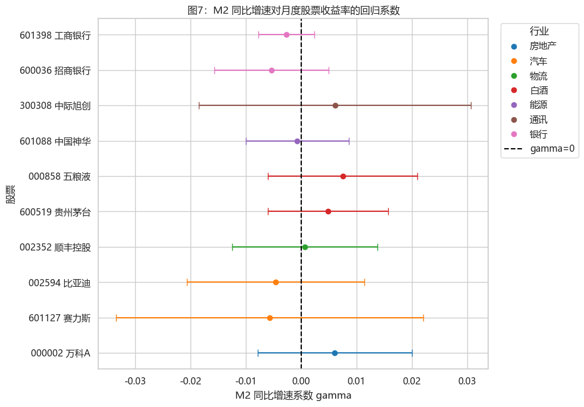

M2 月度回归中，γ 最大的是 五粮液（白酒，γ=0.0075），γ 最小的是 赛力斯（汽车，γ=-0.0057）。显著性方面，没有股票的 M2 系数在 5% 水平上显著；如果系数不显著，说明在本样本中 M2 同比增速对单个股票月收益的解释力有限。

从经济逻辑看，M2 增速代表流动性环境，理论上更充裕的流动性可能提高风险偏好并支持估值。不同行业敏感性差异可能来自融资需求、久期属性、景气周期和政策传导速度不同，因此不能把 γ 简单解释为因果效应。

## 6. 结论

综合来看，样本股票在 2020 年以来的表现分化明显：中际旭创 的年化收益表现突出，赛力斯 的波动更高，万科A 的阶段性回撤压力最大。CAPM 结果表明，部分汽车、通讯和白酒股票 beta 高于 1，市场弹性较强；而 beta 较低或 R² 较低的股票更受个股和行业特质影响。宏观回归中 M2 对单只股票月收益的解释力整体有限，因此宏观变量更适合作为背景变量，而不是单独预测股票收益的充分依据。

方法上，本项目先用 CSV 保留原始和合并数据，再用 Parquet 展示列式存储优势；分析阶段以清洗后的 CSV 为主数据源，保证结果可复现。需要注意的是，CAPM 和宏观回归都是相关性分析，不能单独证明因果关系；后续若要提高解释力，可以加入行业指数、规模因子、价值因子、动量因子和更多公司基本面变量。